# In Connecticut schools spending is up, but students are still struggling

Sasha Allen | allensasha622@gmail.com | 443-386-7386  
June 7, 2025

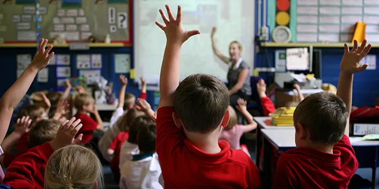

In 2022, one in three students were at risk of dropping of dropping out, and chronic absenteeism continues to be an issue. Despite this, Connecticut has increased spending on education over the past decade.

## So, what’s going on in Connecticut schools?

The state is undergoing what they call the Disconnected Youth Crisis. Students are struggling in multiple aspects of school, and these struggles have long-term consequences. As a result, young people are not entering the job market or pursuing higher education after either dropping out or graduating.

The state created a method of looking at the overall performance of their schools called the Next Generation Accountability System which is based off of 12 broad factor indicators of student performance:

- Academic achievement status measured by state assessments
- Academic growth
- Assessment participation rate
- Chronic absenteeism
- Postsecondary preparation - coursework
- Postsecondary readiness – exams and college credit
- Graduation – on track in ninth grade
- Graduation – four-year adjusted cohort graduation rate – all students
- Graduation – six-year adjusted cohort graduation rate – high needs
- Postsecondary entrance rate – all students (college enrollment)
- Physical fitness
- Arts access

Each school has a point maximum based on the opportunities and level of school, and is given a score and an accountability index, or the percent of the total maximum points earned, to gauge what level a school or district is at.

[interactive chart not shown]

## Funding levels continue to rise as student test scores fall.

Connecticut has increased spending on education over the past decade. Despite this, students in the state are not performing well. In 2022, one in three students were at risk of not graduating high school according to a report released in October of 2023.

[interactive chart not shown]

## How does this compare nationally?

Connecticut spends more on education than most states across the nation. But how much exactly are they spending, and what is the national average for per-pupil spending on education?

[interactive chart not shown]

## State actions

This story is extremely timely because this issue has been brought to light in the past two years. A report was published in October of 2023 detailing the failures of the state, and this report has sparked the introduction of legislation into the Connecticut Senate. The legislation proposed an increase in funding for at-risk students and better data collection methods and data collaboration, but was not passed by the end of session.

The target audience for this story is anyone in Connecticut who is in the school system or knows anyone involved in the school system including parents, teachers, students, family members and friends of students. This way, they can be more informed on what the state is trying to do as well as the contributing factors to the crisis.

## Highly affected districts

Bridegport, Waterbury, Hartford and New Haven have some of the highest rates of poverty in the state. They were also among the ten districts with more than 1,000 students performing at the lowest levels in the state.

[interactive chart not shown]

## People to interview

- Rep. Anthony L. Nolan, introduced a bill to increase education funding.
- Donna Hamzy, helped craft the Young People’s Plan, which is a ten year plan for funding to help the crisis.
- State Department of Education Commissioner Charlene Russell-Tucker
- Someone who testified during the legislative hearings could be a good place to start finding people closely connected to the issue, preferably a student who has experienced disconnection in the school system. (https://www.cga.ct.gov/aspx/CGADisplayTestimonies/CGADisplayTestimony.aspx?bill=SB-01511&doc_year=2025)

## Going forward

I would like to compare the median household income or the poverty rates in each district to the accountability index. I could also take a more micro look at test scores and the factors going into the accountability index.

This could possibly impact the funding for education, although it seems like there is already some initiative to change policy. Hopefully from this more nonprofits will be able to help supplement in high need areas from this as well.

I was mainly interested in this story because I had never heard of the disconnected youth crisis before and for a rich state known for having a fairly good education system, and wondered why so many students were at risk of dropping out.

Estimated delivery is beginning of July.

```r
library(tidyverse)
library(janitor)
library(readxl)
library(rvest)
library(tidycensus)
library(scales)
library(stringr)
library(readr)
```

```r
#disconnected youth data
next_gen <- read.csv("../data/next_gen.csv") |>
    clean_names()
#zip code data (disconnected youth has no zip)
zips_ct <- read.csv("../data/zips_ct.csv")|>
  clean_names()

zips_ct <- zips_ct |> rename(
  reporting_district_code = organization_code,
)

#per pupil funding data split down to the district, 2017 to 2022  https://public-edsight.ct.gov/overview/per-pupil-expenditures-by-function---district/per-pupil-expenditures-by-funding-source---summary?language=en_US

pp_21_22 <- read.csv("../data/per_pupil_2122.csv")|>
  clean_names() |>
  mutate(year = "21-22")

pp_20_21 <- read.csv("../data/per_pupil_2021.csv")|>
  clean_names()|>
  mutate(year = "20-21")

pp_19_20 <- read.csv("../data/per_pupil_1920.csv")|>
  clean_names()|>
  mutate(year = "19-20")

pp_18_19 <- read.csv("../data/per_pupil_1819.csv")|>
  clean_names()|>
  mutate(year = "18-19")

pp_17_18 <- read.csv("../data/per_pupil_1718.csv")|>
  clean_names()|>
  mutate(year = "17-18")

per_pupil_all <- bind_rows(pp_17_18, pp_18_19, pp_19_20, pp_20_21, pp_21_22)

per_pupil_all <- per_pupil_all|> rename(
  reporting_district_code = district_code,
)

#statewide per pupil funding
pp_statewide <- read.csv("../data/per_pupil_state3.csv")|>
  clean_names()

#nationwide per pupil funding
#https://www.census.gov/data/tables/2023/econ/school-finances/secondary-education-finance.html

pp_nation <- read.csv("../data/pp_nation.csv")|>
  clean_names()

#cleaning
pp_nation <- pp_nation |>
  mutate(x = str_remove(x, "\\.+$"))

write_csv(pp_nation, "pp_nation.csv")

#graduation rate
graduation_rate_state<- read.csv("../data/state_graduation.csv")|>
  clean_names()
graduation_rate <- read.csv("../data/graduation_rates1.csv")|>
  clean_names()

#dropout rate by district
dropout_rate <- read.csv("../data/dropout_rates1.csv")|>
  clean_names()

#percent of students in high school for more than four years
still_enrolled <- read.csv("../data/over_four_year_enrollment.csv")|>
  clean_names()

#enrollment by district
enrollment_district <- read.csv("../data/enrollement_district.csv")|>
  clean_names()
```

```r
#converting the year in per-pupil statewide data to just include the year in the fall of the school year so i can use it in the graphs below

pp_statewide <- pp_statewide |>
  mutate(
    # Remove $ and commas, convert to numeric
    ppe_numeric = str_remove_all(ppe, "[$,]") |> as.numeric(),
    # Format numeric values with commas
    ppe_formatted = comma(ppe_numeric)
  )
```

```r
#filter out percent
next_gen_pct <- next_gen |>
  filter(category == "DistrictTot")|>
  select(rptng_district_name, reporting_district_code, total_points, total_possible_points, fall_of_year, accountability_index)

next_gen2022 <- next_gen_pct |>
  filter(fall_of_year == 2022)

write_csv(next_gen2022, "next_gen2022.csv")

#join dataset w/ zips and town name to the disconnected dataset (could use this for viz purposes)
zips_ct_selected <- zips_ct |> select(zipcode, reporting_district_code, town)
zip_percentage <- left_join(next_gen_pct, zips_ct_selected, by = "reporting_district_code")

#zip for 2021-2022 per pupil funding
pp_21_22 <- left_join(pp_21_22, zips_ct_selected, by = c("district_code" = "reporting_district_code"))

#dropout, graduation, and still in school data
dropout_rate <- dropout_rate |> rename(
  reporting_district_code = district_code,
)

still_enrolled <- still_enrolled|> rename(
  reporting_district_code = district_code,
)

graduation_rate <- graduation_rate |> rename(
  reporting_district_code = district_code,
)

dropout_rate <- left_join(dropout_rate, zips_ct_selected, by = "reporting_district_code")

graduation_rate <- left_join(graduation_rate, zips_ct_selected, by = "reporting_district_code")

still_enrolled <- left_join(still_enrolled, zips_ct_selected, by = "reporting_district_code")

#add zips to the per-pupil funding dataset
per_pupil_all <- left_join(per_pupil_all, zips_ct_selected, by = "reporting_district_code")
```

```r
next_gen_pct |>
  filter(fall_of_year == 2022)|>
  arrange(accountability_index)|>
  select(rptng_district_name, accountability_index)
```

```r
#joining the datasets so that i can create a table of the worst performing districts to compare funding and graduation rate
districts <- c(
  "Norwich School District",
  "Sprague School District",
  "Sterling School District",
  "New Britain School District",
  "Bridgeport School District",
  "New London School District",
  "Hartford School District",
  "New Haven School District",
  "Hampton School District",
  "Waterbury School District"
)

filtered_next_gen_pct <- next_gen_pct |>
  filter(fall_of_year == 2021, rptng_district_name %in% districts)

filtered_graduation_rate <- graduation_rate |>
  filter(district %in% districts)

filtered_per_pupil_all <- per_pupil_all |>
  filter(year == "21-22", district %in% districts)

# Join all three datasets
joined_data <- filtered_per_pupil_all |>
  left_join(filtered_graduation_rate |> select(district, x2021_22), by = "district") |>
  left_join(
    filtered_next_gen_pct |> rename(district = rptng_district_name),
    by = "district"
  )

write_csv(joined_data, "joined_data.csv")
```

```r
#this is per-pupil funding stats that combine local, fed and state funding split down by zipcode, just for the 2021 to 2022 school year.
pp_21_22 |>
  arrange(total) |>
  select(total, zipcode, district)
```

```r
#finding districts and zip codes with the highest dropout rates (this is hard because there is not data for all districts)
dropout_rate |>
  arrange(desc(x2021_22)) |>
  select(x2021_22, zipcode, district)
```

```r
graduation_rate |>
  arrange(x2021_22) |>
  select(x2021_22, zipcode, district)
```

```r
next_gen_state <- next_gen |>
  filter(school_name == "State of Connecticut")|>
  select(fall_of_year, category, total_points, total_possible_points, accountability_index)|>
  arrange(fall_of_year)
```

```r
pp_statewide <- pp_statewide |>
  mutate(fall_of_year = str_sub(year, 1, 4) %>% as.numeric())

next_gen_state1 <- next_gen_state |>
    select(fall_of_year, accountability_index)

write_csv(next_gen_state1, "next_gen_state1.csv")

pp_statewide1 <- pp_statewide |>
  select(fall_of_year, ppe_numeric)

write_csv(pp_statewide1, "pp_statewide1.csv")
```

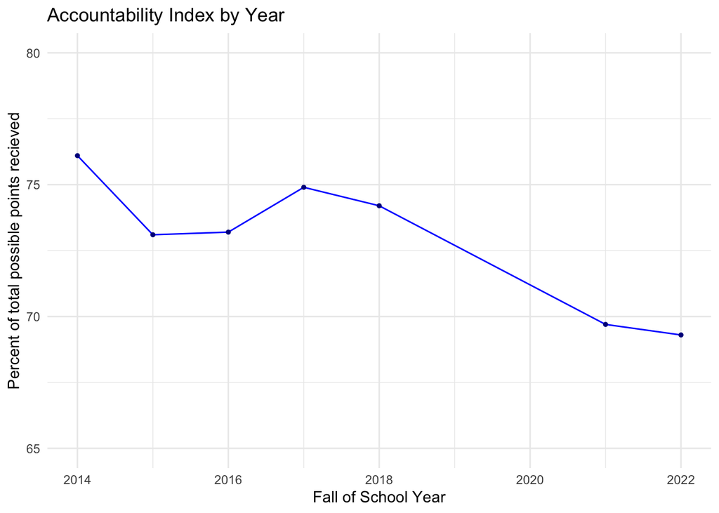

```r
#The higher the accountability index, the better prepared students are. Students have been doing worse in the state since 2014 based on a series of factors. There was no data for 2019 or 2020.
ggplot(next_gen_state, aes(x = fall_of_year, y = accountability_index)) +
  geom_line(color = "blue", size = .5) +
  ylim(65, 80) +
  geom_point(color = "darkblue", size = 1) +  # optional points
  labs(
    #title is horrible but this was just for comparison purposes
    title = "Accountability Index by Year",
    x = "Fall of School Year",
    #this is based on the accountability index scores, or  the percent of the total number of possible points received based on the scoring system
    y = "Percent of total possible points recieved"
  ) +
  theme_minimal()
```